# Risk Factor Analysis

## Outcome Variable

**Outcome Variable:** sstunted

## Predictor Variables

**Intervention Variable:** nhh

**Adjustment Set:**

- arm
- W_mage
- meducyrs
- feducyrs
- hhwealth_quart
- W_mhtcm
- W_mwtkg
- W_mbmi
- W_nrooms
- cleanck
- impfloor
- impsan
- safeh20
- delta_W_mage
- delta_meducyrs
- delta_feducyrs
- delta_hhwealth_quart
- delta_W_mhtcm
- delta_W_mwtkg
- delta_W_mbmi
- delta_W_nrooms
- delta_cleanck
- delta_impfloor
- delta_impsan
- delta_safeh20

## Stratifying Variables

The analysis was stratified on these variable(s):

- agecat
- studyid
- country

## Data Summary

| agecat | studyid | country | nhh | sstunted | n_cell | n |
| --- | --- | --- | --- | --- | --- | --- |
| Birth | ki1000108-IRC | INDIA | 3 or less | 0 | 53 | 388 |
| Birth | ki1000108-IRC | INDIA | 3 or less | 1 | 1 | 388 |
| Birth | ki1000108-IRC | INDIA | 4-5 | 0 | 142 | 388 |
| Birth | ki1000108-IRC | INDIA | 4-5 | 1 | 8 | 388 |
| Birth | ki1000108-IRC | INDIA | 6-7 | 0 | 97 | 388 |
| Birth | ki1000108-IRC | INDIA | 6-7 | 1 | 6 | 388 |
| Birth | ki1000108-IRC | INDIA | 8+ | 0 | 80 | 388 |
| Birth | ki1000108-IRC | INDIA | 8+ | 1 | 1 | 388 |
| Birth | ki1017093-NIH-Birth | BANGLADESH | 3 or less | 0 | 106 | 608 |
| Birth | ki1017093-NIH-Birth | BANGLADESH | 3 or less | 1 | 6 | 608 |
| Birth | ki1017093-NIH-Birth | BANGLADESH | 4-5 | 0 | 248 | 608 |
| Birth | ki1017093-NIH-Birth | BANGLADESH | 4-5 | 1 | 7 | 608 |
| Birth | ki1017093-NIH-Birth | BANGLADESH | 6-7 | 0 | 135 | 608 |
| Birth | ki1017093-NIH-Birth | BANGLADESH | 6-7 | 1 | 3 | 608 |
| Birth | ki1017093-NIH-Birth | BANGLADESH | 8+ | 0 | 100 | 608 |
| Birth | ki1017093-NIH-Birth | BANGLADESH | 8+ | 1 | 3 | 608 |
| Birth | ki1017093b-PROVIDE | BANGLADESH | 3 or less | 0 | 102 | 539 |
| Birth | ki1017093b-PROVIDE | BANGLADESH | 3 or less | 1 | 2 | 539 |
| Birth | ki1017093b-PROVIDE | BANGLADESH | 4-5 | 0 | 250 | 539 |
| Birth | ki1017093b-PROVIDE | BANGLADESH | 4-5 | 1 | 1 | 539 |
| Birth | ki1017093b-PROVIDE | BANGLADESH | 6-7 | 0 | 115 | 539 |
| Birth | ki1017093b-PROVIDE | BANGLADESH | 6-7 | 1 | 1 | 539 |
| Birth | ki1017093b-PROVIDE | BANGLADESH | 8+ | 0 | 68 | 539 |
| Birth | ki1017093b-PROVIDE | BANGLADESH | 8+ | 1 | 0 | 539 |
| Birth | ki1017093c-NIH-Crypto | BANGLADESH | 3 or less | 0 | 108 | 732 |
| Birth | ki1017093c-NIH-Crypto | BANGLADESH | 3 or less | 1 | 0 | 732 |
| Birth | ki1017093c-NIH-Crypto | BANGLADESH | 4-5 | 0 | 322 | 732 |
| Birth | ki1017093c-NIH-Crypto | BANGLADESH | 4-5 | 1 | 6 | 732 |
| Birth | ki1017093c-NIH-Crypto | BANGLADESH | 6-7 | 0 | 173 | 732 |
| Birth | ki1017093c-NIH-Crypto | BANGLADESH | 6-7 | 1 | 3 | 732 |

[output cut: 90 more lines]

The following strata were considered:

- agecat: 24 months, studyid: ki1000108-IRC, country: INDIA
- agecat: 24 months, studyid: ki1017093-NIH-Birth, country: BANGLADESH
- agecat: 24 months, studyid: ki1017093b-PROVIDE, country: BANGLADESH
- agecat: 24 months, studyid: ki1017093c-NIH-Crypto, country: BANGLADESH
- agecat: 24 months, studyid: ki1148112-LCNI-5, country: MALAWI
- agecat: 6 months, studyid: ki1000108-IRC, country: INDIA
- agecat: 6 months, studyid: ki1000304b-SAS-FoodSuppl, country: INDIA
- agecat: 6 months, studyid: ki1017093-NIH-Birth, country: BANGLADESH
- agecat: 6 months, studyid: ki1017093b-PROVIDE, country: BANGLADESH
- agecat: 6 months, studyid: ki1017093c-NIH-Crypto, country: BANGLADESH
- agecat: 6 months, studyid: ki1148112-LCNI-5, country: MALAWI
- agecat: Birth, studyid: ki1000108-IRC, country: INDIA
- agecat: Birth, studyid: ki1017093-NIH-Birth, country: BANGLADESH
- agecat: Birth, studyid: ki1017093b-PROVIDE, country: BANGLADESH
- agecat: Birth, studyid: ki1017093c-NIH-Crypto, country: BANGLADESH

### Dropped Strata

Some strata were dropped due to rare outcomes:

- agecat: Birth, studyid: ki1000108-IRC, country: INDIA
- agecat: Birth, studyid: ki1017093-NIH-Birth, country: BANGLADESH
- agecat: Birth, studyid: ki1017093b-PROVIDE, country: BANGLADESH
- agecat: Birth, studyid: ki1017093c-NIH-Crypto, country: BANGLADESH
- agecat: 6 months, studyid: ki1000108-IRC, country: INDIA
- agecat: 6 months, studyid: ki1000304b-SAS-FoodSuppl, country: INDIA
- agecat: 6 months, studyid: ki1017093-NIH-Birth, country: BANGLADESH
- agecat: 6 months, studyid: ki1017093b-PROVIDE, country: BANGLADESH
- agecat: 6 months, studyid: ki1017093c-NIH-Crypto, country: BANGLADESH
- agecat: 24 months, studyid: ki1000108-IRC, country: INDIA

## Methods Detail

We’re interested in the causal parameters $E[Y_a]$ for all values of $a \in \mathcal{A}$. These parameters represent the mean outcome if, possibly contrary to fact, we intervened to set all units to have $A=a$. Under the randomization and positivity assumptions, these are identified by the statistical parameters $\psi_a=E_W[E_{Y|A,W}(Y|A=a,W)]$. In addition, we’re interested in the mean of $Y$, $E[Y]$ under no intervention (the observed mean). We will estimate these parameters by using SuperLearner to fit the relevant likelihood factors – $E_{Y|A,W}(Y|A=a,W)$ and $p(A=a|W)$, and then updating our likelihood fit using a joint TMLE.

For unadjusted analyses ($W=\{\}$), initial likelihoods were estimated using Lrnr_glm to estimate the simple $E(Y|A)$ and Lrnr_mean to estimate $p(A)$. For adjusted analyses, a small library containing Lrnr_glmnet, Lrnr_xgboost, and Lrnr_mean was used.

Having estimated these parameters, we will then use the delta method to estimate relative risks and attributable risks relative to a prespecified baseline level of $A$.

# Results Detail

## Results Plots

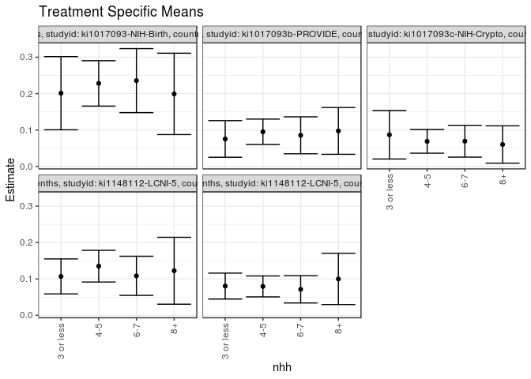

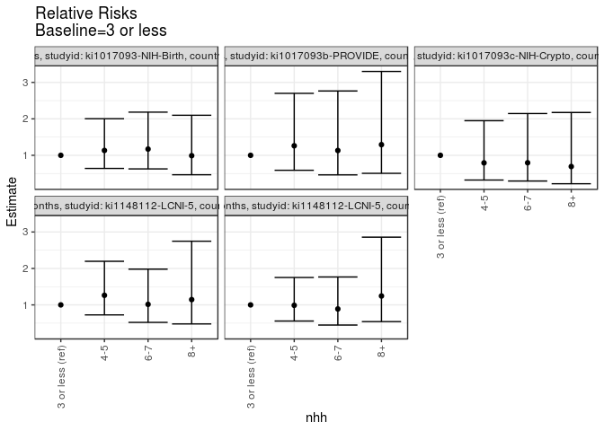

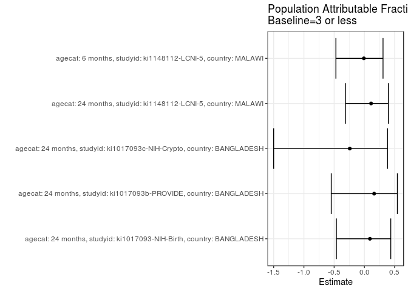

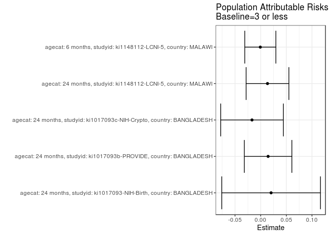

## Results Table

### Parameter: TSM

| agecat | studyid | country | intervention_level | baseline_level | estimate | ci_lower | ci_upper |
| --- | --- | --- | --- | --- | --- | --- | --- |
| 6 months | ki1148112-LCNI-5 | MALAWI | 3 or less | NA | 0.0803571 | 0.0447356 | 0.1159786 |
| 6 months | ki1148112-LCNI-5 | MALAWI | 4-5 | NA | 0.0794118 | 0.0506543 | 0.1081692 |
| 6 months | ki1148112-LCNI-5 | MALAWI | 6-7 | NA | 0.0714286 | 0.0339897 | 0.1088674 |
| 6 months | ki1148112-LCNI-5 | MALAWI | 8+ | NA | 0.1000000 | 0.0296787 | 0.1703213 |
| 24 months | ki1017093-NIH-Birth | BANGLADESH | 3 or less | NA | 0.2011462 | 0.1006881 | 0.3016043 |
| 24 months | ki1017093-NIH-Birth | BANGLADESH | 4-5 | NA | 0.2280335 | 0.1656633 | 0.2904037 |
| 24 months | ki1017093-NIH-Birth | BANGLADESH | 6-7 | NA | 0.2356617 | 0.1477117 | 0.3236118 |
| 24 months | ki1017093-NIH-Birth | BANGLADESH | 8+ | NA | 0.1992061 | 0.0874885 | 0.3109237 |
| 24 months | ki1017093b-PROVIDE | BANGLADESH | 3 or less | NA | 0.0754717 | 0.0251421 | 0.1258013 |
| 24 months | ki1017093b-PROVIDE | BANGLADESH | 4-5 | NA | 0.0952381 | 0.0603871 | 0.1300891 |
| 24 months | ki1017093b-PROVIDE | BANGLADESH | 6-7 | NA | 0.0854701 | 0.0347667 | 0.1361735 |
| 24 months | ki1017093b-PROVIDE | BANGLADESH | 8+ | NA | 0.0975610 | 0.0332827 | 0.1618392 |
| 24 months | ki1017093c-NIH-Crypto | BANGLADESH | 3 or less | NA | 0.0869565 | 0.0204073 | 0.1535058 |
| 24 months | ki1017093c-NIH-Crypto | BANGLADESH | 4-5 | NA | 0.0689655 | 0.0363273 | 0.1016037 |
| 24 months | ki1017093c-NIH-Crypto | BANGLADESH | 6-7 | NA | 0.0692308 | 0.0255521 | 0.1129095 |
| 24 months | ki1017093c-NIH-Crypto | BANGLADESH | 8+ | NA | 0.0602410 | 0.0090037 | 0.1114783 |
| 24 months | ki1148112-LCNI-5 | MALAWI | 3 or less | NA | 0.1069182 | 0.0588454 | 0.1549911 |
| 24 months | ki1148112-LCNI-5 | MALAWI | 4-5 | NA | 0.1350211 | 0.0914743 | 0.1785679 |
| 24 months | ki1148112-LCNI-5 | MALAWI | 6-7 | NA | 0.1085271 | 0.0548048 | 0.1622495 |
| 24 months | ki1148112-LCNI-5 | MALAWI | 8+ | NA | 0.1224490 | 0.0305856 | 0.2143124 |

### Parameter: E(Y)

| agecat | studyid | country | intervention_level | baseline_level | estimate | ci_lower | ci_upper |
| --- | --- | --- | --- | --- | --- | --- | --- |
| 6 months | ki1148112-LCNI-5 | MALAWI | NA | NA | 0.0796569 | 0.0610679 | 0.0982459 |
| 24 months | ki1017093-NIH-Birth | BANGLADESH | NA | NA | 0.2214452 | 0.1821080 | 0.2607825 |
| 24 months | ki1017093b-PROVIDE | BANGLADESH | NA | NA | 0.0899654 | 0.0666186 | 0.1133122 |
| 24 months | ki1017093c-NIH-Crypto | BANGLADESH | NA | NA | 0.0700389 | 0.0479542 | 0.0921236 |
| 24 months | ki1148112-LCNI-5 | MALAWI | NA | NA | 0.1202091 | 0.0935816 | 0.1468365 |

### Parameter: RR

| agecat | studyid | country | intervention_level | baseline_level | estimate | ci_lower | ci_upper |
| --- | --- | --- | --- | --- | --- | --- | --- |
| 6 months | ki1148112-LCNI-5 | MALAWI | 3 or less | 3 or less | 1.0000000 | 1.0000000 | 1.000000 |
| 6 months | ki1148112-LCNI-5 | MALAWI | 4-5 | 3 or less | 0.9882353 | 0.5575312 | 1.751667 |
| 6 months | ki1148112-LCNI-5 | MALAWI | 6-7 | 3 or less | 0.8888889 | 0.4474248 | 1.765936 |
| 6 months | ki1148112-LCNI-5 | MALAWI | 8+ | 3 or less | 1.2444444 | 0.5419491 | 2.857541 |
| 24 months | ki1017093-NIH-Birth | BANGLADESH | 3 or less | 3 or less | 1.0000000 | 1.0000000 | 1.000000 |
| 24 months | ki1017093-NIH-Birth | BANGLADESH | 4-5 | 3 or less | 1.1336703 | 0.6413017 | 2.004062 |
| 24 months | ki1017093-NIH-Birth | BANGLADESH | 6-7 | 3 or less | 1.1715943 | 0.6283413 | 2.184534 |
| 24 months | ki1017093-NIH-Birth | BANGLADESH | 8+ | 3 or less | 0.9903547 | 0.4673994 | 2.098425 |
| 24 months | ki1017093b-PROVIDE | BANGLADESH | 3 or less | 3 or less | 1.0000000 | 1.0000000 | 1.000000 |
| 24 months | ki1017093b-PROVIDE | BANGLADESH | 4-5 | 3 or less | 1.2619048 | 0.5897546 | 2.700112 |
| 24 months | ki1017093b-PROVIDE | BANGLADESH | 6-7 | 3 or less | 1.1324786 | 0.4638776 | 2.764755 |
| 24 months | ki1017093b-PROVIDE | BANGLADESH | 8+ | 3 or less | 1.2926829 | 0.5062512 | 3.300791 |
| 24 months | ki1017093c-NIH-Crypto | BANGLADESH | 3 or less | 3 or less | 1.0000000 | 1.0000000 | 1.000000 |
| 24 months | ki1017093c-NIH-Crypto | BANGLADESH | 4-5 | 3 or less | 0.7931034 | 0.3225095 | 1.950371 |
| 24 months | ki1017093c-NIH-Crypto | BANGLADESH | 6-7 | 3 or less | 0.7961538 | 0.2952860 | 2.146600 |
| 24 months | ki1017093c-NIH-Crypto | BANGLADESH | 8+ | 3 or less | 0.6927711 | 0.2206393 | 2.175187 |
| 24 months | ki1148112-LCNI-5 | MALAWI | 3 or less | 3 or less | 1.0000000 | 1.0000000 | 1.000000 |
| 24 months | ki1148112-LCNI-5 | MALAWI | 4-5 | 3 or less | 1.2628444 | 0.7261728 | 2.196138 |
| 24 months | ki1148112-LCNI-5 | MALAWI | 6-7 | 3 or less | 1.0150479 | 0.5200694 | 1.981125 |
| 24 months | ki1148112-LCNI-5 | MALAWI | 8+ | 3 or less | 1.1452581 | 0.4775888 | 2.746329 |

### Parameter: PAR

| agecat | studyid | country | intervention_level | baseline_level | estimate | ci_lower | ci_upper |
| --- | --- | --- | --- | --- | --- | --- | --- |
| 6 months | ki1148112-LCNI-5 | MALAWI | 3 or less | NA | -0.0007003 | -0.0309954 | 0.0295949 |
| 24 months | ki1017093-NIH-Birth | BANGLADESH | 3 or less | NA | 0.0202990 | -0.0758595 | 0.1164576 |
| 24 months | ki1017093b-PROVIDE | BANGLADESH | 3 or less | NA | 0.0144937 | -0.0318642 | 0.0608516 |
| 24 months | ki1017093c-NIH-Crypto | BANGLADESH | 3 or less | NA | -0.0169176 | -0.0779707 | 0.0441355 |
| 24 months | ki1148112-LCNI-5 | MALAWI | 3 or less | NA | 0.0132908 | -0.0284190 | 0.0550006 |

### Parameter: PAF

| agecat | studyid | country | intervention_level | baseline_level | estimate | ci_lower | ci_upper |
| --- | --- | --- | --- | --- | --- | --- | --- |
| 6 months | ki1148112-LCNI-5 | MALAWI | 3 or less | NA | -0.0087912 | -0.4707235 | 0.3080551 |
| 24 months | ki1017093-NIH-Birth | BANGLADESH | 3 or less | NA | 0.0916661 | -0.4631336 | 0.4360935 |
| 24 months | ki1017093b-PROVIDE | BANGLADESH | 3 or less | NA | 0.1611030 | -0.5478798 | 0.5453471 |
| 24 months | ki1017093c-NIH-Crypto | BANGLADESH | 3 or less | NA | -0.2415459 | -1.4999876 | 0.3834225 |
| 24 months | ki1148112-LCNI-5 | MALAWI | 3 or less | NA | 0.1105642 | -0.3128563 | 0.3974237 |